# Exponential Distribution Simulation and Tooth Growth Analysis

Ash Chakraborty

Wednesday, June 17, 2015

# Overview

This report consists of two parts. Part 1 conducts a number of simulations on the exponential distribution in order to compare it to the central limit theorem, whereas Part 2 analyzes and tests certain hypotheses about Tooth growth’s relationship with certain supplements.

# PART 1: SIMULATION - Sampling the Exponential Distribution

## Synopsis

Part 1 of this report investigates the *Exponential Distribution* and compares it to the *Central Limit Theorem*. The exponential distribution is given by the probability distribution function, $P(x)=\lambda e^{-\lambda x}$. We also know that it has a mean, $\mu = 1/\lambda$, and variance, $\sigma^{2}=1/\lambda^{2}$. This report will conduct an appropriate number of simulations on this distribution with a sample size of 40 exponentials by generating a sampling distribution of sample means. The consequences of this sampling distribution will be evaluated for adherence to the central limit theorem.

## Exponential Distribution

We are to work with a sample size, n = 40 with a rate parameter, $\lambda = 0.2$. We first generate a sample of 40 random exponentials:

```r
library(PerformanceAnalytics)
library(ggplot2)
library(gridExtra)
set.seed(123)
sample <- rexp(40, rate = 0.2)
```

## Simulating 1000 Trials

In order to understand the properties of the distribution of the mean of 40 exponentials, we conduct a 1000 simulations, and extract the mean of each sample:

```r
samp.dist <- NULL
for(i in 1:1000){
        #extract sample of 40 and take mean of that sample
        samp.dist <- c(samp.dist, mean(rexp(40, rate=0.2)))
}
summary(samp.dist)
```

```
##    Min. 1st Qu.  Median    Mean 3rd Qu.    Max.
##   2.943   4.478   4.982   5.014   5.524   7.717
```

### Comparing Variance and Mean to Theoretical Variance and Mean

Now, we plot this sampling distribution:

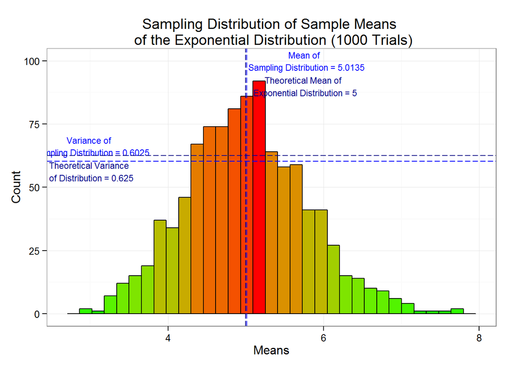

The distribution of a 1000 means of 40 random exponentials has begun to resemble a Gaussian distribution.

We continue to note from the earlier plot that the sampling distribution’s mean and variance may be given by:

```
## [1] "Mean of Sampling Distribution: 5.0135"
```

```
## [1] "Variance of Distribution: 0.6025"
```

We noted earlier that the theoretical mean of the exponential distribution is given by $1/\lambda$ ($\lambda = 0.2$), which is equal to 5. When we compare the sampling distribution’s mean to this theoretical mean, we see that it is a fairly good approximation.

Furthermore, the theoretical variance of the sampling distribution is given by the variance of the population mean/sample size, or $(1/\lambda^{2})/n$, which = 0.625. Here, it seems that the variance obtained from the sampling distribution of 0.6025, is a fair approximation of the theoretical variance of the sampling distribution obtained from the population mean.

## Verifying Distribution Normality

In order to confirm that the sampling distribution obtained above is indeed normal, we will test a consequence of the central limit theorem, i.e. *as the sample size approaches infinity, the variation of the sampling distribution gets smaller* and thus results in a closer approximation of the population mean.

We will therefore conduct two simulations with greater sample sizes, n= 100 and n = 1000. We will conduct a 1000 trials and compute the variance, kurtosis and skew to give us an idea of the density curve. **Note: we are looking for these parameters to get smaller, in order to approach a proper normal distribution**.

```r
#sim 1, sample size = 100
samp.dist1 <- NULL
for(i in 1:1000){
        #extract sample of 100 #take mean of that sample
        samp.dist1 <- c(samp.dist1, mean(rexp(100, rate=0.2)))
}

#sim 2, sample size=1000
samp.dist2 <- NULL
for(i in 1:1000){
        #extract sample of 1000 #take mean of that sample
        samp.dist2 <- c(samp.dist2, mean(rexp(1000, rate=0.2)))
}
```

Plotting the resulting sampling distributions side by side:

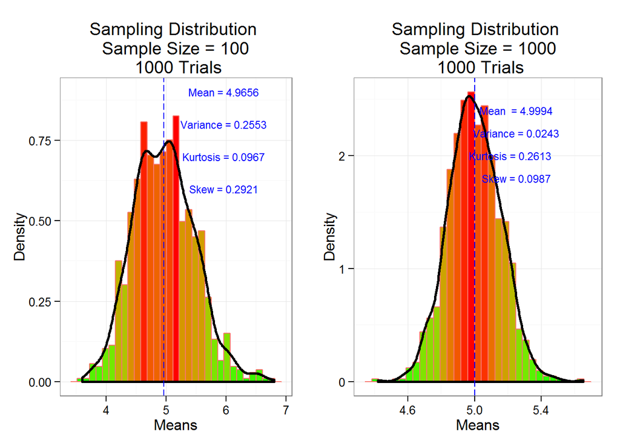

Consequently, we observe the following:

- The mean is approximated more closely as the sample size increases (in line with CLT)
- Variance of sampling distribution significantly decreases (in line with CLT)
- The skew of the density curve get smaller, suggesting a normal curve

We can thus conclude that the sampling distribution of means of the exponential distribution approaches a normal distribution as the sample sizes increase. This is in line with the Central Limit Theorem!

**END OF PART 1**

# PART 2: Analyzing Tooth Growth Data

## Synopsis

We are going to load the ToothGrowth dataset that’s part of the “datasets” package in R. The dataset contains 60 observations of tooth length measured while under the administration of supplements “OJ” and “VC” in various dosages. We run some summary analysis on this dataset, in addition to testing hypotheses to extract any relationships between supplement, dosage, and tooth length.

## Data Summary

We see that the dataset is setup as follows:

```
##       len        supp         dose
##  Min.   : 4.20   OJ:30   Min.   :0.500
##  1st Qu.:13.07   VC:30   1st Qu.:0.500
##  Median :19.25           Median :1.000
##  Mean   :18.81           Mean   :1.167
##  3rd Qu.:25.27           3rd Qu.:2.000
##  Max.   :33.90           Max.   :2.000
```

At this point, given the lack of any supporting documentation, we state some assumptions about the data itself:

- “len” represents the length of tooth growth in an unknown unit
- “supp” represents the supplements used in this experiment: “OJ”, “VC”
- “dose” regulates the amount of supplement administered. It is discrete and units are unknown.

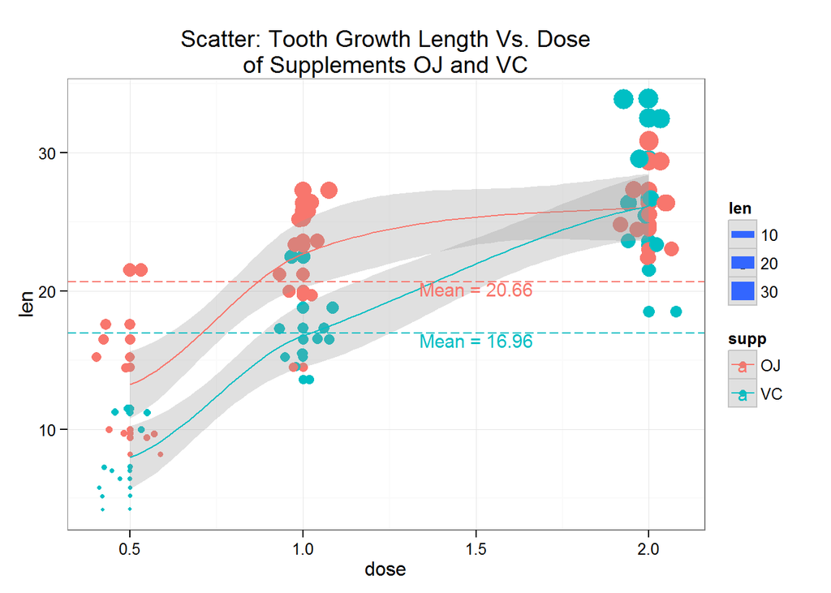

The plot *seems to* suggest the following:

- There is a positive correlation between length and dosage amount 0.5 and 1.0 for both supplements.
- There is no data for either supplement at dosage amount 1.5.
- Any effect on length at dosage amount of 2.0 for either supplement is unclear.
- Overall, the average sample tooth growth length is greater for “OJ” than it is for “VC”.

## Hypothesis Testing

Given the summary above, we setup the following tests to help determine the effect of the 2 supplements and their doses on tooth growth. For the tests, the following assumptions are made:

- These are independent groups, i.e. the subjects in each dose group are *not* the same.
- The variances unequal, and are allowed to be corrected by the t.test function

In the first test (which serves as the template for the subsequent tests), we compare the effect on tooth growth between supplements OJ and VC at dose = 0.5. We assume that the NULL hypothesis, $H_0:\mu_{xOJ}=\mu_{xVC}$, is true.

```r
# Function to take in the dosage group and perform a t-test on supplement effect on length
doseTest <- function(d) {
        testdf <- NULL
        testdf <- subset(ToothGrowth, dose==d, select=c('len', 'supp'))

        # apply t.test to compare the mean lengths by supplement at the dosage group
        t.test(len ~ supp, paired=FALSE, data=testdf)
}

doseTest(0.5)
```

```
##
##  Welch Two Sample t-test
##
## data:  len by supp
## t = 3.1697, df = 14.969, p-value = 0.006359
## alternative hypothesis: true difference in means is not equal to 0
## 95 percent confidence interval:
##  1.719057 8.780943
## sample estimates:
## mean in group OJ mean in group VC
##            13.23             7.98
```

Here, we see that the 95% confidence interval is above zero, suggesting that the mean of supplement OJ at dose=0.5 is larger than the mean of VC at the same dose. The p value of 0.64% is very unlikely, thus causing us to **reject** the NULL hypothesis.

Similarly, we repeat the *t-test* to compare the 2 supplements in dose groups 1.0 and 2.0, respectively:

```r
doseTest(1)
```

```
##
##  Welch Two Sample t-test
##
## data:  len by supp
## t = 4.0328, df = 15.358, p-value = 0.001038
## alternative hypothesis: true difference in means is not equal to 0
## 95 percent confidence interval:
##  2.802148 9.057852
## sample estimates:
## mean in group OJ mean in group VC
##            22.70            16.77
```

```r
doseTest(2)
```

```
##
##  Welch Two Sample t-test
##
## data:  len by supp
## t = -0.0461, df = 14.04, p-value = 0.9639
## alternative hypothesis: true difference in means is not equal to 0
## 95 percent confidence interval:
##  -3.79807  3.63807
## sample estimates:
## mean in group OJ mean in group VC
##            26.06            26.14
```

# Assumptions and Conclusions

The following assumptions must be restated for the tests conducted above:

- The subjects in each dosage groups are independent, i.e. the distribution in each group is not paired
- Unequal variance between groups has been assumed
- In the absence of population means and standard deviations, the sample means and standard deviations of each group have been used in calculating the standard error of the mean and t-stats.

**END OF REPORT**

# APPENDIX 1: GIT CODE

The entire markdown file can be found in this [github repo](https://github.com/ashirwad08/StatisticalInference.git).

# APPENDIX 2: PLOT CODE BLOCKS

## (PART 1) Comparing Variance and Mean to Theoretical Variance and Mean

```r
#sampling distribution of sample means
g3 <- ggplot()
g3+geom_histogram(aes(x=samp.dist, fill=..count..), col="black")+
        scale_fill_gradient("Count",
                            low = "green",
                            high = "red")+

        #mean of sampling dist.
        geom_vline(aes(xintercept=mean(samp.dist)),
                   linetype="longdash",
                   col="blue")+
        geom_text(aes(x=mean(samp.dist)*1.15,
                      y=100,
                      label=paste0("Mean of \n Sampling Distribution = ",
                                   round(mean(samp.dist), 4))
                      ),
                  col="blue", size=3
                  )+
        #theoretical mean
        geom_vline(aes(xintercept=1/0.2),
                       linetype="longdash",
                       col="darkblue"
                   )+
        geom_text(aes(x=(1/0.2)*1.15,
                      y=90,
                      label=paste0("Theoretical Mean of \n Exponential Distribution = ",
                                   round(1/0.2, 4))
                      ),
                  col="darkblue", size=3
                  )+

        #variance of sampling dist.
        geom_hline(aes(yintercept=var(samp.dist)*100),
                       linetype="longdash",
                       col="blue"
                   )+
        geom_text(aes(y=var(samp.dist)*110,
                      x=3,
                      label=paste0("Variance of \n Sampling Distribution = ",
                                   round(var(samp.dist), 4))
                      ),
                  col="blue", size=3
                  )+
        #theoretical variance = population variance/n
        geom_hline(aes(yintercept=((1/(0.2^2))/40)*100),
                       linetype="longdash",
                       col="darkblue")+
        geom_text(aes(y=((1/(0.2^2))/40)*90,
                      x=3,
                      label=paste0("Theoretical Variance \n of Distribution = ",
                                   round(((1/(0.2^2))/40), 4))
                      ),
                  col="darkblue", size=3
                  )+
        labs(title="Sampling Distribution of Sample Means \n of the Exponential Distribution (1000 Trials)",
                x="Means", y="Count")+
        theme_bw()+
        theme(legend.position="none")
```

## (PART 1) Verifying Normality

```r
# PLOT SIM 1
g4 <- ggplot() + geom_histogram(aes(x=samp.dist1,
                                    y=..density..,
                                    fill=..count..,
                                    col="black"))+
        scale_fill_gradient("Count",
                            low = "green",
                            high = "red")+
        geom_density(aes(samp.dist1), col="black", size=1)+

        #mean of sampling dist.
        geom_vline(aes(xintercept=mean(samp.dist1)),
                   linetype="longdash",
                   col="blue")+
        geom_text(aes(x=mean(samp.dist1)*1.2,
                      y=.9,
                      label=paste0("Mean = ",
                                   round(mean(samp.dist1), 4))
                      ),
                  col="blue", size=3
                  )+

        #variance of sampling dist.
        geom_text(aes(y=.8,
                      x=mean(samp.dist1)*1.2,
                      label=paste0("Variance = ",
                                   round(var(samp.dist1), 4))
                      ),
                  col="blue", size=3
                  )+

        #kurtosis
        geom_text(aes(y=.7,
                      x=mean(samp.dist1)*1.2,
                      label=paste0("Kurtosis = ", round(kurtosis(samp.dist1), 4))
                      ),
                  col="blue", size=3
                  )+

        #skew
        geom_text(aes(y=.6,
                      x=mean(samp.dist1)*1.2,
                      label=paste0("Skew = ", round(skewness(samp.dist1), 4))
                      ),
                  col="blue", size=3
                  )+

        labs(title="Sampling Distribution \n Sample Size = 100 \n 1000 Trials",
                x="Means", y="Density")+
        theme_bw()+
        theme(legend.position="none")

# PLOT SIM 2
g5 <- ggplot() + geom_histogram(aes(x=samp.dist2,
                                    y=..density..,
                                    fill=..count..,
                                    col="black"))+
        scale_fill_gradient("Count",
                            low = "green",
                            high = "red")+
        geom_density(aes(samp.dist2), col="black", size=1)+

        #mean of sampling dist.
        geom_vline(aes(xintercept=mean(samp.dist2)),
                   linetype="longdash",
                   col="blue")+
        geom_text(aes(x=mean(samp.dist2)*1.05,
                      y=.9+1.5,
                      label=paste0("Mean  = ",
                                   round(mean(samp.dist2), 4))
                      ),
                  col="blue", size=3
                  )+

        #variance of sampling dist.
        geom_text(aes(y=.8+1.4,
                      x=mean(samp.dist2)*1.05,
                      label=paste0("Variance = ",
                                   round(var(samp.dist2), 4))
                      ),
                  col="blue", size=3
                  )+

        #kurtosis
        geom_text(aes(y=.7+1.3,
                      x=mean(samp.dist1)*1.05,
                      label=paste0("Kurtosis = ", round(kurtosis(samp.dist2), 4))
                      ),
                  col="blue", size=3
                  )+

        #skew
        geom_text(aes(y=.6+1.2,
                      x=mean(samp.dist2)*1.05,
                      label=paste0("Skew = ", round(skewness(samp.dist2), 4))
                      ),
                  col="blue", size=3
                  )+

        labs(title="Sampling Distribution \n Sample Size = 1000 \n 1000 Trials",
                x="Means", y="Density")+
        theme_bw()+
        theme(legend.position="none")

grid.arrange(g4, g5, ncol=2)
```

## (PART 2) ToothGrowth Summary

```r
g1 <- ggplot(data=ToothGrowth, aes(x=dose, y=len, group=supp, col=supp, size=len) )
g1 + geom_point()+
        geom_jitter(position=position_jitter(width=0.1))+
        geom_smooth(alpha=0.3, method="loess")+
        geom_hline(data=means.df, aes(yintercept=c(means[[1]], means[[2]]), col=supp), linetype="longdash")+
        geom_text(data=means.df, aes(x=1.5, y=c(means[[1]], means[[2]]), col=supp,
                                     label=c(paste0("Mean = ", round(means[[1]], 2)),
                                             paste0("Mean = ", round(means[[2]], 2)))),
                                             size=4, vjust=1)+
        labs(title="Scatter: Tooth Growth Length Vs. Dose\nof Supplements OJ and VC") +
        theme_bw()
```